#### Hop Variety Network

##### Coursera SNA Peer Assessment Project, Autumn 2014 Edition

##### **Introduction**

*Humulus lupulus* (common hop or hop) is a species of flowering plant in the Cannabaceae family, native to Europe, western Asia and North America. *H. lupulus* is the main ingredient of many beers, and as such is widely cultivated for use by the brewing industry ([Wikipedia](https://en.wikipedia.org/wiki/Humulus_lupulus)).

Different types of beers are brewed with different hops. By effect, there are two main hop types: **bittering** and **finishing** (aroma). The effect of a hop on the brew is determined by the composition of its resin, mainly by the content of the so-called alpha- and beta-acids. Bittering hops have higher concentrations of alpha acids, and are responsible for the large majority of the bitter flavor of a beer. Aroma hops usually have a lower concentration of alpha acids (~5%) and are the primary contributors of hop aroma and (nonbitter) flavor ([Wikipedia](https://en.wikipedia.org/wiki/Hops)). Altogether, there are at present at least ~140 hop varieties in use ([Wikipedia](https://en.wikipedia.org/wiki/List_of_hop_varieties) ).

Professional brewers and homebrewers are, obviously, aware of the differences between hop varieties. I’m not one of them, though. I’m, in fact, a complete abnegate when it comes to beers. I’ve just only recently tasted beer with a very different taste to the beers I’m used to and got curious about it (it turned out to contain one of the rarer New Zealand hops, and I’m in Europe). So, for this project, I’ve decided to expand my own knowledge and explore the wonderful world of hops. I think I’ve learnt a lot, but the usefulness of this project for **you** will definitely depend on how much you know about beer and brewing already. :-)

##### **Data Acquisition**

I created the dataset by combining information from several resources:  
- https://en.wikipedia.org/wiki/List_of_hop_varieties  
- http://www.beeradvocate.com/beer/101/hops/  
- http://www.brewerylane.com/hops_profiles.html  
- https://freshops.com/hops/variety_descriptions  
- http://www.bear-flavored.com/2011/12/bear-flavoreds-ultimate-guide-to-hop.html  
- http://www.homebrewstuff.com/hop-profiles  
- http://beersmith.com/hop-list/

For each hop variety, I tried to obtain the following information:  
- Name  
- Type (bittering, finishing or dual-purpose)  
- Country of origin  
- Alpha-acid content  
- Beta-acid content  
- Types of beer where hop is used  
- Possible substitutes.

Not all data was available for each variety. Also, in particular, reported alpha-acid content sometimes differed between sources - a content of 9-12% reported by one source could be reported as 10-15% in another. Hence, alpha-acid data should be treated in an approximate and relative way (i.e. a hop with reported alpha 9-12% is almost certain to have higher alpha than a hop with reported alpha 3-3.5%; on the other hand, it’s inconclusive whether it really has a lower alpha than a 10-15% hop).

I created the network based on the variety-substitution data. I.e.:  
- each hop variety corresponded to a single node (vertex);  
- in-edges were created from varieties mentioned by at least one expert/source as possible variety substitute.

For example:  
Hallertau can be substituted *by* Saaz, Hersbrucker or Tettnang

so the following edges were created:  
Saaz –> Hallertau (Saaz can substitute *for* Hallertau)  
Hersbrucker –> Hallertau  
Tettnang –> Hallertau

##### **Initial Data Exploration and Visualisation**

I chose R with the igraph package as my analysis tool.

```r
library(igraph)
library(ggplot2)
library(gridExtra)
hops_vert <- read.delim("./hops_vert.txt")
hops_edg <- read.delim("./hops_edg.txt")
hopg <- graph.data.frame(hops_edg, vertices=hops_vert, directed=TRUE)
```

The following visualisation shows the network with vertices coloured by country of hop origin (black: continental Europe [Germany, France, Czech Republic, Slovenia, Poland, Russia], blue: UK, red: US, orange: Australia and New Zealand, purple: Japan).

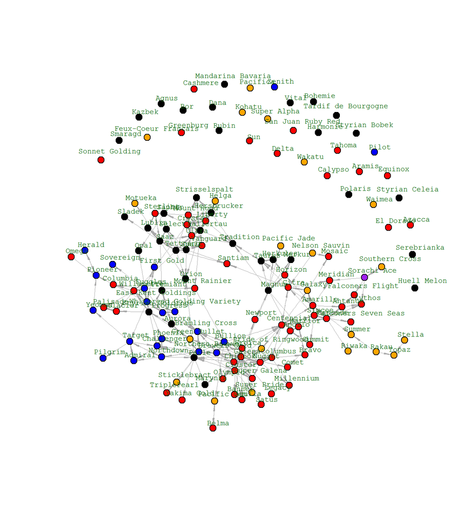

```r
hopcountmap <- c("orange", "black", "black", "black", "purple", "orange", "black", "black", "black", "blue", "red")
plot.igraph(hopg, layout=layout.fruchterman.reingold(graph=hopg, area=200^2), vertex.size=4, vertex.color=hopcountmap[hops_vert$Country], vertex.label.cex=0.7, vertex.label.family='mono', vertex.label.dist=0.25, vertex.label.color="dark green", edge.width=0.5, edge.arrow.size=0.5, edge.arrow.width=0.3)
```

The following visualisation shows the network with vertices coloured by the type of hop (brown: bittering, yellow: finishing, black: dual-purpose, grey: unknown).

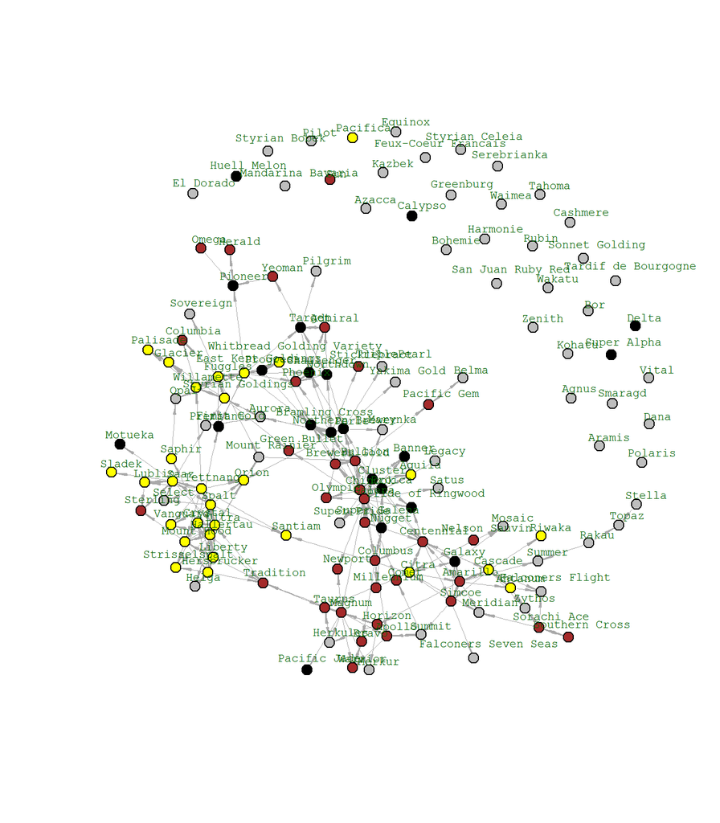

```r
hoptypemap <- c("brown", "black", "yellow", "grey")
plot.igraph(hopg, layout=layout.fruchterman.reingold(graph=hopg, area=200^2), vertex.size=4, vertex.color=hoptypemap[hops_vert$Type], vertex.label.cex=0.7, vertex.label.family='mono', vertex.label.dist=0.25, vertex.label.color="dark green", edge.width=0.5, edge.arrow.size=0.5, edge.arrow.width=0.3)
```

The following visualisation shows the network with vertices coloured by averaged alpha-acid content (yellow: <=6%, orange: <=14%, red: >14%, up to 21%).

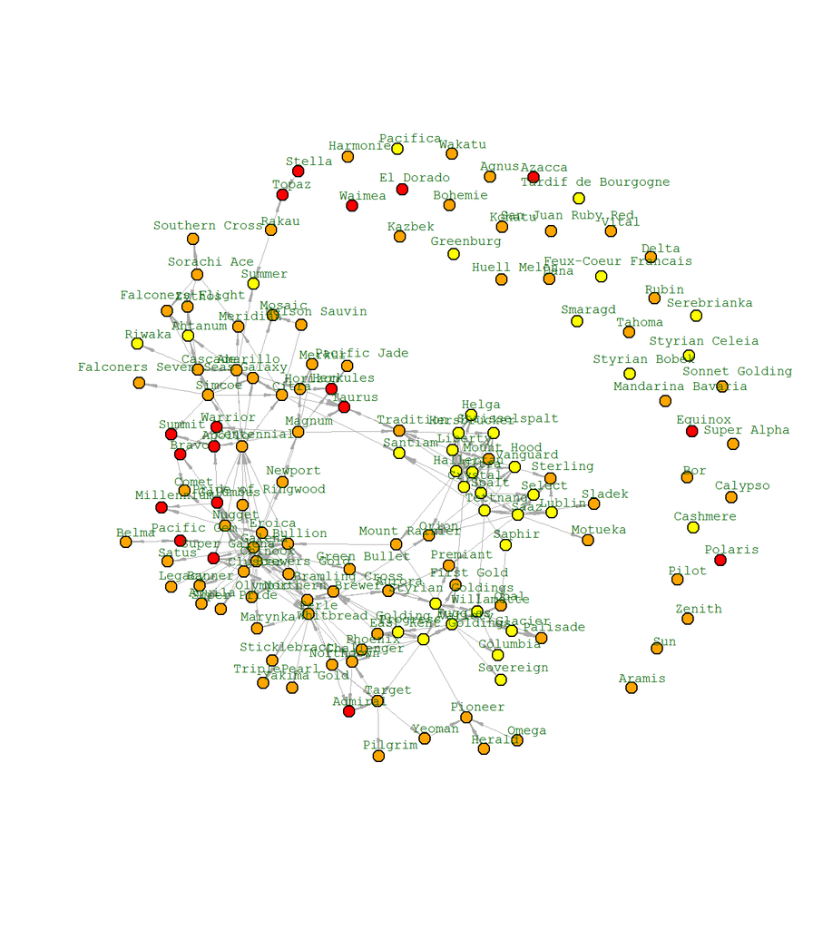

```r
hops_vert$avalpha <- (hops_vert$Alpha_min+hops_vert$Alpha_max)/2
hops_vert$Alphatype <- as.factor(ifelse(hops_vert$avalpha<=6, "1", ifelse(hops_vert$avalpha<=14, "2", "3")))
hopalphamap <- c("yellow", "orange", "red")
plot.igraph(hopg, layout=layout.fruchterman.reingold(graph=hopg, area=200^2), vertex.size=4, vertex.color=hopalphamap[hops_vert$Alphatype], vertex.label.cex=0.7, vertex.label.family='mono', vertex.label.dist=0.25, vertex.label.color="dark green", edge.width=0.5, edge.arrow.size=0.5, edge.arrow.width=0.3)
```

These visualisations already tell some history of hop variety differentiation. For example, traditional UK hops group together. German noble hops also group together (those are the ones like Hallertau or Saaz). German high-alpha hops also group together. And a lot of the ungrouped varieties are high-alpha (which means they are new) or from Eastern Europe (which means that the American brewers would have a more limited access to them).

Nevertheless, since this is an SNA Peer Assessment project, and it requires me to treat the network quantitatively - let’s start, seriously, from the quantitative metrics. From this point on, I’ll treat the graph as undirected:

##### **Quantitative Network Analysis**

**1. Network summary.**

```r
summary(as.undirected(hopg))
```

```
## IGRAPH UN-- 141 235 --
## + attr: name (v/c), Country (v/c), Alpha (v/c), Beta (v/c), Beer
## | (v/c), Type (v/c), Sub (v/c), Alpha_min (v/n), Alpha_max (v/n),
## | Beta_min (v/n), Beta_max (v/n)
```

Named undirected graph with 141 vertices and 235 edges. If I still treated it as directed, there would be 297 edges - some would be counted twice for each direction.

**2. Degree distribution.**

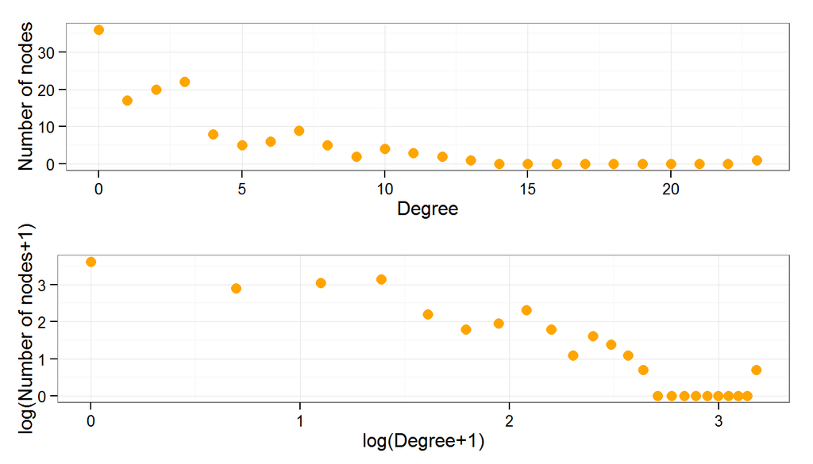

```r
x <- seq(0,23)
y <- 141*degree.distribution(as.undirected(hopg))
d <- as.data.frame(cbind(x, y))
p <- ggplot(d, aes(x,y))+geom_point(color="orange", size=3) + theme_bw()+xlab("Degree") + ylab ("Number of nodes")
q <- ggplot(d, aes(log(x+1),log(y+1)))+geom_point(color="orange", size=3) + theme_bw()+xlab("log(Degree+1)") + ylab ("log(Number of nodes+1)")
grid.arrange(p,q, nrow=2)
```

The network is too small to make sound conclusions about the mode of attachment (preferential or not).

**3. Nodes with maximum degrees.**

```r
hop_deg <- degree(as.undirected(hopg))
ord_hop_deg <- order(hop_deg)
tail(hop_deg[ord_hop_deg])
```

```
##            Cluster East Kent Goldings            Chinook
##                 11                 11                 12
##          Hallertau    Northern Brewer             Galena
##                 12                 13                 23
```

```r
tail(hops_vert[ord_hop_deg, c(1,2,3,4,6)])
```

```
##                  Name Country   Alpha    Beta         Type
## 24            Cluster      US 5.5-8.5 4.5-5.5 Dual purpose
## 54 East Kent Goldings      UK   4-5.5 2.0-3.0    Finishing
## 22            Chinook      US   12-14 3.0-4.0    Bittering
## 44          Hallertau Germany 3.5-5.5 3.5-5.5    Finishing
## 71    Northern Brewer      UK    8-10 3.0-5.0 Dual purpose
## 40             Galena      US   12-14 7.5-9.0    Bittering
```

These appear to be either old hop varieties, or varieties bred for “generic”, “mainstream” purposes. It seems sensible that there would be many substitutes for them.

**4. Nodes with high betweenness.**

```r
hop_bet <- betweenness(as.undirected(hopg), normalized=TRUE)
ord_hop_bet <- order(hop_bet)
tail(hop_bet[ord_hop_bet])
```

```
##            Bullion             Magnum              Perle
##         0.06268757         0.06782463         0.07101299
## East Kent Goldings         Centennial             Galena
##         0.07651126         0.11214723         0.16998327
```

```r
tail(hops_vert[ord_hop_bet, c(1,2,3,4,6)])
```

```
##                  Name Country    Alpha    Beta         Type
## 16            Bullion      UK    6.5-9 3.2-4.7    Bittering
## 58             Magnum Germany    11-17 5.0-7.0    Bittering
## 81              Perle Germany     6-10 4.0-5.0 Dual purpose
## 54 East Kent Goldings      UK    4-5.5 2.0-3.0    Finishing
## 20         Centennial      US 9.5-11.5 4.0-5.0    Bittering
## 40             Galena      US    12-14 7.5-9.0    Bittering
```

On the other hand, apart from East Kent Goldings, these nodes aren’t old/traditional. Instead, going by the definition of betweenness, those are varieties that are simply frequently used with connection with others, rarer varieties.

**5. Community detection.**

```r
fc <-  fastgreedy.community(as.undirected(hopg))
sizes(fc)
```

```
## Community sizes
##  1  2  3  4  5  6  7  8  9 10 11 12 13 14 15 16 17 18 19 20 21 22 23 24 25
## 26 19 18 10 20 12  1  1  1  1  1  1  1  1  1  1  1  1  1  1  1  1  1  1  1
## 26 27 28 29 30 31 32 33 34 35 36 37 38 39 40 41 42
##  1  1  1  1  1  1  1  1  1  1  1  1  1  1  1  1  1
```

This is the meat of the network description problem. The FastGreedy algorithm detects 6 communities with size >1. The modularity (listed below) is similar to that given by e.g. the Walktrap algorithm, so I think this is the best one can do.

Here are the communities:

```r
modularity(fastgreedy.community(as.undirected(hopg)))
```

```
## [1] 0.6299864
```

Community 1 appears to be composed primarily of mainstream dual-purpose and bittering hops, mainly from the UK and the US (e.g. Perle, Chinook, Cluster, Galena). Think American lager… but really, these are the “basis” of hops.

```r
hops_vert[membership(fc)==1, c(1,2,3,4,6)]
```

```
##                  Name     Country     Alpha    Beta         Type
## 6              Aquila          US     6-7.5       3    Finishing
## 9              Banner          US      9-11       4 Dual purpose
## 10              Belma          US        12              Unknown
## 15       Brewers Gold          UK       6-9     3.7    Bittering
## 16            Bullion          UK     6.5-9 3.2-4.7    Bittering
## 20         Centennial          US  9.5-11.5 4.0-5.0    Bittering
## 22            Chinook          US     12-14 3.0-4.0    Bittering
## 24            Cluster          US   5.5-8.5 4.5-5.5 Dual purpose
## 26           Columbus          US     14-18 4.5-5.5    Bittering
## 33             Eroica          US      9-12   4-5.5 Dual purpose
## 40             Galena          US     12-14 7.5-9.0    Bittering
## 55             Legacy          US       7-8              Unknown
## 60            Marynka      Poland      7-10              Unknown
## 63         Millennium          US     13-16     4.8    Bittering
## 71    Northern Brewer          UK      8-10 3.0-5.0 Dual purpose
## 72             Nugget          US     12-14 4.0-6.0 Dual purpose
## 73            Olympic          US     11-13            Bittering
## 77        Pacific Gem New Zealand     14-16     8.2    Bittering
## 81              Perle     Germany      6-10 4.0-5.0 Dual purpose
## 88  Pride of Ringwood   Australia      7-10 5.3-6.5 Dual purpose
## 97              Satus          US   12.5-14 8.5-9.0      Unknown
## 110      Sticklebract New Zealand     11-14       8    Bittering
## 118       Super Pride   Australia    9-10.5   5.5-6      Unknown
## 121      Super Galena          US     13-16            Bittering
## 129       TriplePearl          US 10.2-11.2 3.3-4.2      Unknown
## 138       Yakima Gold          US  8.8-10.5 4.3-5.0      Unknown
```

Community 2 are “fun”, “interesting”, fruity hops (Galaxy, Simcoe, Mosaic, Sorachi Ace). Think American Pale Ales.

```r
hops_vert[membership(fc)==2, c(1,2,3,4,6)]
```

```
##                     Name     Country     Alpha     Beta         Type
## 3                Ahtanum          US   5.7-6.3  5.0-6.5    Finishing
## 4               Amarillo          US      8-11      6-7    Bittering
## 18               Cascade          US   7.7-9.1  5.0-7.0    Finishing
## 23                 Citra          US     11-13 3.5 -4.5    Finishing
## 34      Falconers Flight          US      10.5               Unknown
## 35  Falconers Seven Seas          US      9-10               Unknown
## 39                Galaxy   Australia     13-15   5.8- 6 Dual purpose
## 61              Meridian          US       6-7               Unknown
## 64                Mosaic          US 11.5-13.5  3.2-3.9      Unknown
## 68         Nelson Sauvin New Zealand     12-14      6-8    Bittering
## 90                 Rakau New Zealand      9-11      4.6      Unknown
## 91                Riwaka New Zealand   4.5-6.5             Finishing
## 100               Simcoe          US     12-14  4.0-5.0    Bittering
## 104          Sorachi Ace       Japan 10.0-16.0             Bittering
## 105       Southern Cross New Zealand 11.0-14.0      6.2    Bittering
## 108               Stella   Australia     14-16    4-4.5      Unknown
## 116               Summer   Australia      4 -7  4.8-6.1      Unknown
## 127                Topaz   Australia   15.5-18      6-7      Unknown
## 140               Zythos          US     10-12               Unknown
```

Community 3 are primarily traditional British aroma/finishing hops and US hops bred to substitute for them (East Kent Goldings, Bramling Cross). Think traditional British ales, porters, stouts…

```r
hops_vert[membership(fc)==3, c(1,2,3,4,6)]
```

```
##                          Name     Country    Alpha    Beta         Type
## 13             Bramling Cross          UK 5.0-10.0       3 Dual purpose
## 25                   Columbia          US      5.5       3    Bittering
## 37                 First Gold          UK  6.5-8.5     3.5 Dual purpose
## 38                    Fuggles          UK    4-5.5 1.5-2.0    Finishing
## 41                    Glacier          US      5.5     7.6    Finishing
## 42               Green Bullet New Zealand    11-14     7.0    Bittering
## 54         East Kent Goldings          UK    4-5.5 2.0-3.0    Finishing
## 67              Mount Rainier          US      5-8              Unknown
## 75                       Opal     Germany     8-10              Unknown
## 80                   Palisade          US     6-10            Finishing
## 87                   Premiant   Czech Rep     7-10              Unknown
## 89                   Progress          UK      5-7     2.1 Dual purpose
## 96                     Saphir     Germany    2-4.5            Finishing
## 106                 Sovereign          UK      4-7              Unknown
## 112                    Aurora    Slovenia  7.0-9.5              Unknown
## 115          Styrian Goldings    Slovenia    4.5-6     2-3    Finishing
## 136 Whitbread Golding Variety          UK  5.0-8.0     2.5    Finishing
## 137                Willamette          US      4-6 3.5-4.5    Finishing
```

Community 4 are again primarily traditional British hops, but this time bittering hops (Admiral, Challenger, Yeoman, Pioneer). Again, think British ales.

```r
hops_vert[membership(fc)==4, c(1,2,3,4,6)]
```

```
##           Name Country    Alpha  Beta         Type
## 1      Admiral      UK  13.5-16   5.6    Bittering
## 21  Challenger      UK  6.5-8.5 4-4.5 Dual purpose
## 47      Herald      UK    11-13   5.2    Bittering
## 70   Northdown      UK  7.5-9.5   5.5 Dual purpose
## 74       Omega      US     9-11          Bittering
## 82     Phoenix      UK     9-13   4.6    Bittering
## 83     Pilgrim      UK     9-13            Unknown
## 85     Pioneer      UK     8-10   3.8 Dual purpose
## 124     Target      UK 9.5-12.5 5-5.5 Dual purpose
## 139     Yeoman      UK     9-14          Bittering
```

Community 5 are the mainly the traditional low-alpha continental noble aroma hops and hops bred as substitutes (Saaz, Spalt, Tettnang). Think classic German lagers, Wheats or Altbiers (old beers). Saaz is the sole variety used for the Czech Pilsner Urquell.

```r
hops_vert[membership(fc)==5, c(1,2,3,4,6)]
```

```
##              Name     Country   Alpha    Beta         Type
## 28        Crystal          US 3.5-5.5 5.0-6.7    Finishing
## 44      Hallertau     Germany 3.5-5.5 3.5-5.5    Finishing
## 46          Helga   Australia   5-6.3     4.6      Unknown
## 49    Hersbrucker     Germany   3-5.5    4 -6    Finishing
## 56        Liberty          US     3-5 3.0-3.5    Finishing
## 57         Lublin      Poland     3-5     3.0    Finishing
## 65        Motueka New Zealand 6.5-7.5         Dual purpose
## 66     Mount Hood          US     5-8 5.0-7.5    Finishing
## 76          Orion     Germany     6-8     3.7    Finishing
## 93           Saaz   Czech Rep   3-4.5   3-4.5    Finishing
## 95        Santiam          US     5-7       7    Finishing
## 98         Select     Germany     4-6              Unknown
## 101        Sladek   Czech Rep   4.5-8            Finishing
## 107         Spalt     Germany     4-5 3.0-4.5    Finishing
## 109      Sterling          US     6-9 5.0-6.0    Bittering
## 111 Strisselspalt      France     3-5     3.8    Finishing
## 126      Tettnang     Germany 3.5-5.5 3.5-4.5    Finishing
## 128     Tradition     Germany   10-13     4.5    Bittering
## 130         Ultra          US   4.5-5 3.6-4.7    Finishing
## 131      Vanguard          US   5.5-6 5.0-7.0    Finishing
```

```r
hops_vert[membership(fc)==6, c(1,2,3,4,6)]
```

```
##             Name     Country     Alpha    Beta         Type
## 5         Apollo          US     20-21  5.5 -8    Bittering
## 14         Bravo          US     14-17            Bittering
## 27         Comet          US      9-11     4.5    Bittering
## 48      Herkules     Germany 12.0-17.0              Unknown
## 50       Horizon          US     11-13 6.5-8.5    Bittering
## 58        Magnum     Germany     11-17 5.0-7.0    Bittering
## 62        Merkur     Germany     12-15              Unknown
## 69       Newport          US     10-17            Bittering
## 78  Pacific Jade New Zealand     12-14         Dual purpose
## 117       Summit          US     17-19              Unknown
## 125       Taurus     Germany     12-17            Bittering
## 135      Warrior          US     15-17 4.5-5.5    Bittering
```

Here is the visualisation of the community division:

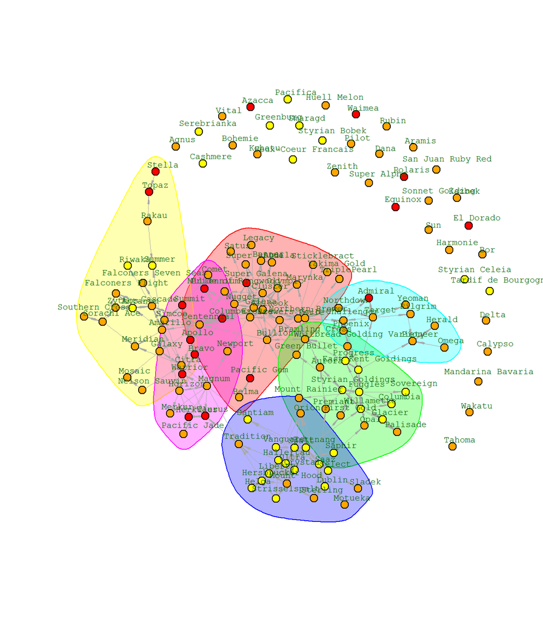

```r
plot.igraph(hopg, layout=layout.fruchterman.reingold(graph=hopg, area=200^2), vertex.size=4, vertex.color=hopalphamap[hops_vert$Alphatype], vertex.label.cex=0.7, vertex.label.family='mono', vertex.label.dist=0.25, vertex.label.color="dark green", edge.width=0.5, edge.arrow.size=0.5, edge.arrow.width=0.3, mark.groups=list(V(hopg)[membership(fc)==1], V(hopg)[membership(fc)==2], V(hopg)[membership(fc)==3], V(hopg)[membership(fc)==4], V(hopg)[membership(fc)==5], V(hopg)[membership(fc)==6]))
```

**Bonus: Assortativity**  
The assortativity coefficient is positive if similar vertices (based on some external property) tend to connect to each, and negative otherwise. Assortativity was only used in the course in quizzes, so I hope its inclusion here will satisfy the point “was at least one additional technique, not covered in the course materials, applied to the data?”. If not… welp.

I think it might be fun to calculate the assortativity with respect to the three attributes I used in the initial visualisation: country of hop origin, type of hop and averaged alpha-acid content.

So:

```r
hops_vert$cgroup <- ifelse(hops_vert$Country %in% c("Germany", "France", "Poland", "Czech Rep", "Slovenia", "Russia"), "cont", ifelse(hops_vert$Country %in% c("Australia", "New Zealand"), "AusNZ", as.character(hops_vert$Country)))
hops_vert$cgroup <- as.factor(hops_vert$cgroup)
assortativity(as.undirected(hopg), hops_vert$cgroup)
```

```
## [1] 0.2466121
```

```r
assortativity(as.undirected(hopg), hops_vert$Type)
```

```
## [1] 0.2656281
```

```r
assortativity(as.undirected(hopg), hops_vert$Alphatype)
```

```
## [1] 0.5373829
```

Apparently, the feature that guarantees the highest assortativity is the alpha-acid content. This makes sense - it’s the alpha-acid content that determines the role of the hop in the beer. (For all that matters, I ignored the beta-acid content throughout this work because it’s less variable - and less important - than the alpha-acid content.)

##### **Limitations of the Data and Future Direction**

The data I used, as mentioned in the Data Acquisition part, was far from perfect. Incomplete, combined from several subjective sources, with alpha-acid content data that was reported differently between sources. It also didn’t yield a lot of novel insight. That’s all right, as far as I’m concerned. It wasn’t supposed to. It was supposed to help me organise information I was not acquainted with. Though I think it might be entertaining to ask a professional brewer their opinion on whether it would be possible to substitute hops from the same communities that are not listed as direct substitutes. :-)

More importantly, the data did not take into consideration *verbal* descriptions of hop varieties. These are important for the finishing/aroma hops. For example, the Nelson Sauvin variety is described in the Bear Flavored blog as “White wine, grapefruit, tangy berries. Dank and intensely fruity. Extremely unique” while Galaxy is “Tropical passionfruit, citrus hints of peach, mango.” Similarity between aroma hops should include similarity between the descriptions of their aromas, and, I think, it might be interesting to look into that.

##### **Final Words**

Well, that was fun! I hope that you are not a teetotaller, a Muslim, or a beer brewer, and so you also got something from this project. If you’d like to know more about beers and how to pair them with food, [this](http://www.splendidtable.org/story/the-7-flavor-categories-of-beer-what-they-are-how-to-pair-them) is a great link. Hops are only part of the picture, after all - there are also different malts. *Salut!*